# Презентация по лабораторной работе №2

Модель SIR

Люпп Софья Романовна

1132236039@rudn.ru

Российский университет дружбы народов

2026-03-07

# Информация

## Докладчик

- Люпп Софья Романовна
- студентка группы НКНбд-01-23
- кафедра теории вероятностей и кибербезопасности
- Российский университет дружбы народов им. П. Лумумбы
- [1132236039@rudn.ru]
- https://github.com/srluipp

# Вводная часть

## Актуальность

Модель SIR (Susceptible‑Infected‑Recovered) остаётся одним из фундаментальных инструментов в эпидемиологии, позволяя оценивать динамику распространения инфекций в популяциях.Модель Лотки–Вольтерра остаётся актуальной, поскольку её простота и гибкость позволяют моделировать динамику взаимодействия популяций в экологических, экономических и эпидемиологических системах, а также интегрировать её с современными данными и машинным обучением.

## Объект и предмет исследования

Обьектами исследования являются модели SIR и Лотки-Вольтерры, а также задачи, которые они решают.

## Цели и задачи

Изучить модель SIR,модель Лотки–Вольтерры, узнать их практическое применение, изучить трехпараметрическую модель и ее практическую ценность. Задачи: 1) Создать и запустить программный код с моделью SIR; 2) Создать и запустить программный код модели Лотки–Вольтерры; 3) Выполнить практическое задание в конце лабораторной работы.

## Материалы и методы

В качестве материалов к выполнению лабораторной работы была использована работа Имитационное моделирование. Практикум. (А. В. Королькова Кулябов Д. С.)

# Выполнение лабораторной работы

## Динамика эффективного репродуктивного числа

В plots оказались следующие графики: динамика эффективного репродуктивного числа, которая падает к 40 дню (рис. 1).

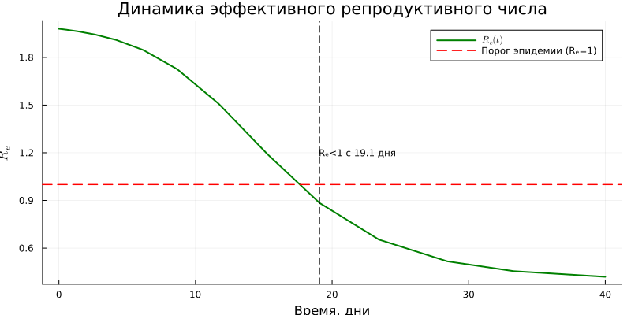

Рисунок 1: dinamic

## Динамика числа зараженных

Динамика числа зараженнных, где пик всех зараженных приходится на 19 день (рис. 2).

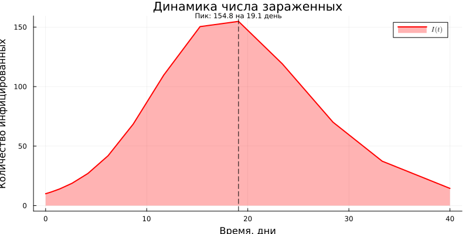

Рисунок 2: infecteddinamic

## Лог-шкала экспоненциального роста

(рис. 3) .

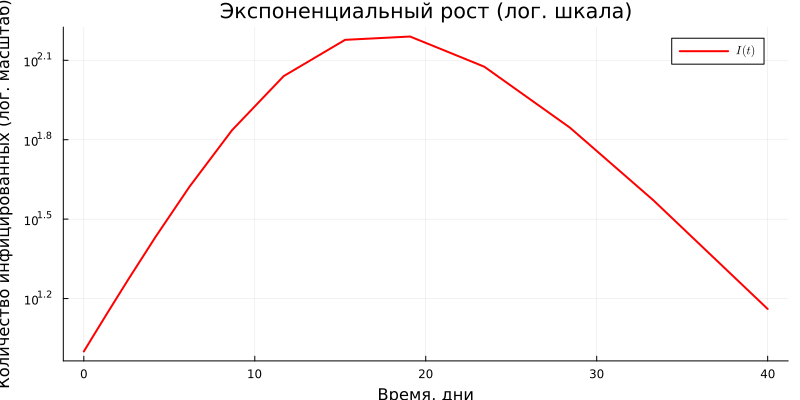

Рисунок 3: exponencialgrowth

## Модель SIR

Сама модель, показывающая динамику восприимчивых, инфицированных и выздоровевших (рис. 4)

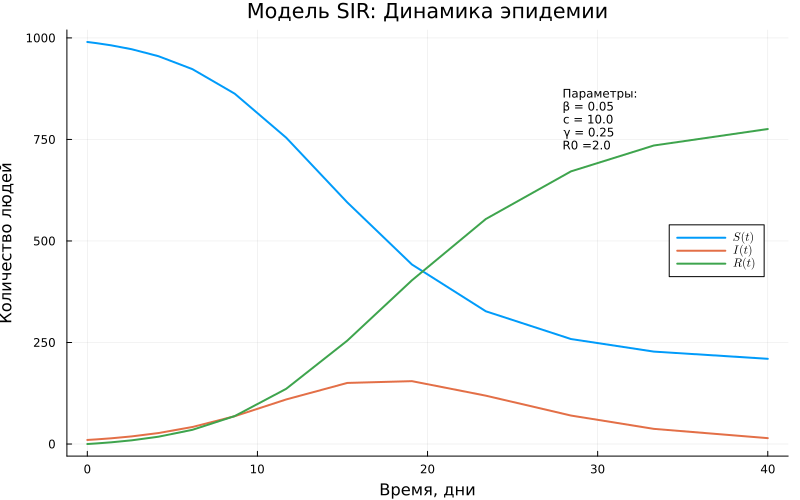

Рисунок 4: sirmodel

## График-вывод для всех групп

Далее выводятся все графики для каждой из групп по раздельности (рис. 5).

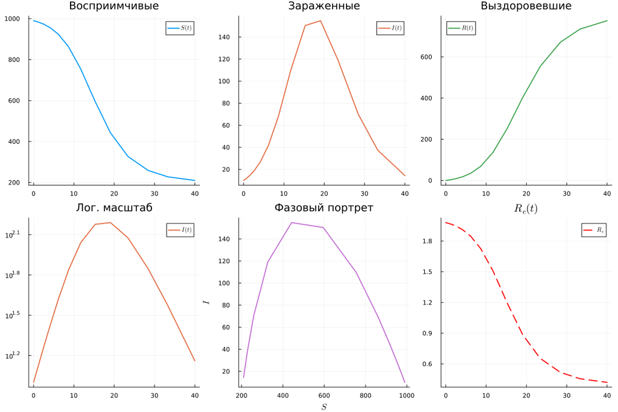

Рисунок 5: grafs

## Динамика эпидемии

Показательна динамика эпидемии в процентах с порогом коллективного иммунитета в 50% (рис. 6).

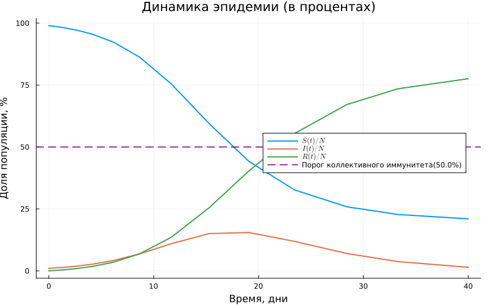

Рисунок 6: percentage

## Фазовый портрет модели SIR

Завершаем анализ фазовым портретом модели sir(рис. 7) .

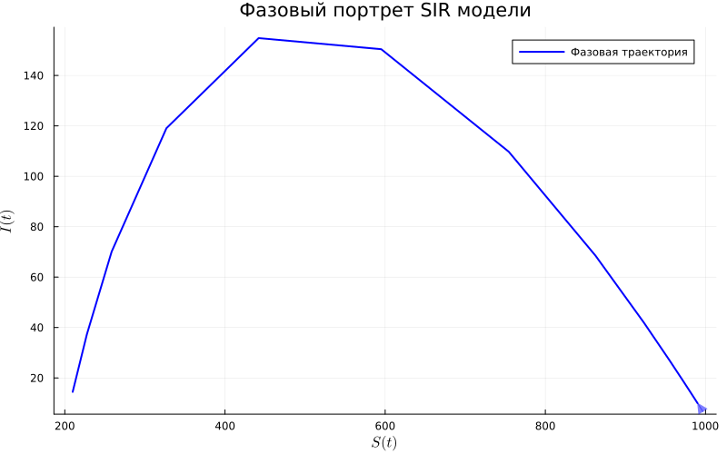

Рисунок 7: phaseportrait

## График производной популяции

Далее рассматриваем модель Лотки-Вольтерры: выводим график производных популяций (рис. 8).

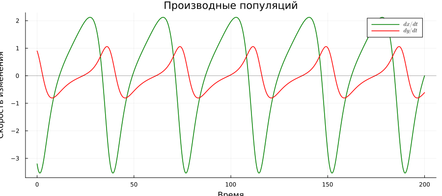

Рисунок 8: population

## Динамика популяций жертв и хищников

(рис. 9).

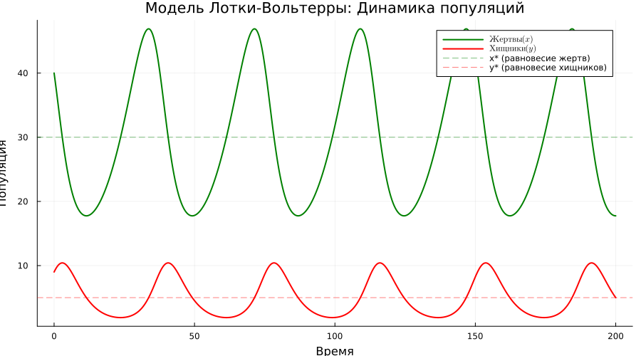

Рисунок 9: dinamicpopulation

## Графики для каждой популяции

Общий график для каждой популяции, фазовый портрет, скорость изменения и относительные изменения(рис. 10)

[figure not shown]

Рисунок 10: bigscheme

## Фазовый портрет

Фазовый портрет системы со стационарной точкой в 30 жертв и 5 хищников (рис. 11)

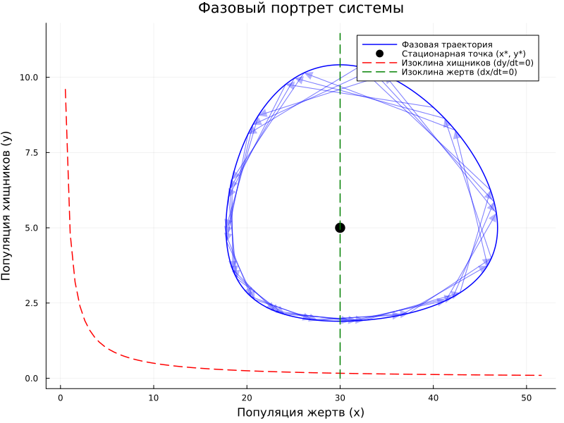

Рисунок 11: phase

## Относительные темпы роста по времени

(рис. 12).

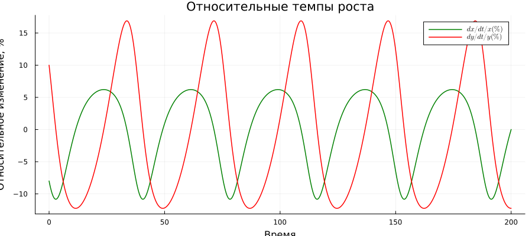

Рисунок 12: growth

## Спектральный анализ Фурье

(рис. 13)

[figure not shown]

Рисунок 13: fyrie

## Результаты

Результатами лабораторной работы явялются представленные графики моделей Лотки-Вольтерры и SIR.

## Итоговый слайд

В результате лабораторной работы я узнала где применимы модели Лотки-Волтерра

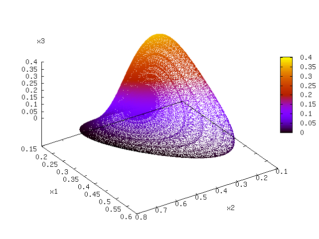

## И модель SIR

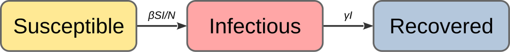